# myers-lydia-ada-hw-2

## ADA HW 2

## Challenge 1

Loading packages and data

```r
library(tidyverse)
```

```r
library(mosaic)
library(gridExtra)
d<-read_csv("https://raw.githubusercontent.com/difiore/ada-2021-datasets/master/IMDB-movies.csv",col_names=T)
```

Filtering data

```r
d<-filter(d, startYear %in% 1920:1979  & runtimeMinutes %in% 60:180)
d<-mutate(d, "decade"=paste(10*as.integer(as.numeric(substring(as.character(d$startYear), 3, 4)) / 10)))
head(d)
```

```
## # A tibble: 6 x 11
##   tconst  titleType primaryTitle  startYear runtimeMinutes genres  averageRating
##   <chr>   <chr>     <chr>             <dbl>          <dbl> <chr>           <dbl>
## 1 tt0010… movie     The Cabinet …      1920             76 Fantas…           8.1
## 2 tt0011… movie     Leaves From …      1920            167 Drama             6.7
## 3 tt0011… movie     Dr. Jekyll a…      1920             82 Drama,…           7
## 4 tt0011… movie     The Golem          1920             76 Fantas…           7.2
## 5 tt0011… movie     The Last of …      1920             73 Action…           6.7
## 6 tt0011… movie     The Mark of …      1920            107 Advent…           7.1
## # … with 4 more variables: numVotes <dbl>, nconst <chr>, director <chr>,
## #   decade <chr>
```

Plotting histograms

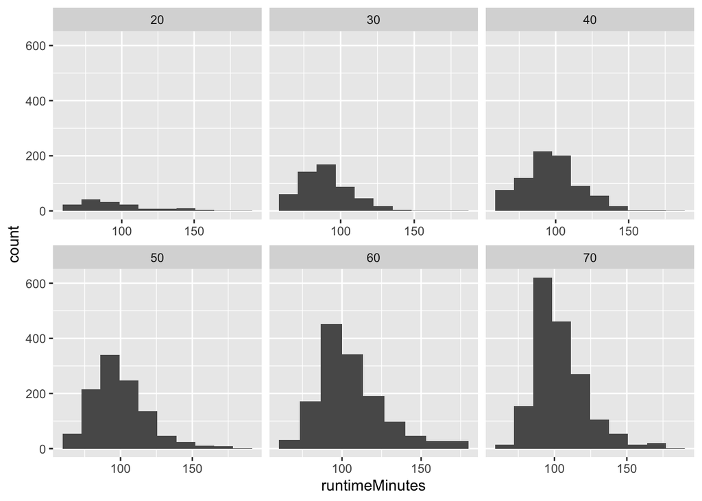

```r
ggplot(d, aes(x=runtimeMinutes)) + geom_histogram(bins=10)+
  facet_wrap(~decade,scales='free_x')
```

Calculating mean and sd

```r
print(results <- summarise((group_by(d,decade)), avg = mean(runtimeMinutes, na.rm = T),
  sd=sd(runtimeMinutes,na.rm=T)))
```

```
## # A tibble: 6 x 3
##   decade   avg    sd
##   <chr>  <dbl> <dbl>
## 1 20      96.3  26.2
## 2 30      90.3  17.3
## 3 40      97.2  19.1
## 4 50      98.9  19.2
## 5 60     106.   21.2
## 6 70     104.   18.0
```

Creating a sample, estimating sample mean, standard deviation, and standard error

```r
set.seed(100)
print(sample <- d %>% group_by(decade) %>% sample_n(100,replace=F)%>%
  summarise(sampleMean=mean(runtimeMinutes,na.rm=T),
      sampleSD=sd(runtimeMinutes,na.rm=T)))
```

```
## # A tibble: 6 x 3
##   decade sampleMean sampleSD
##   <chr>       <dbl>    <dbl>
## 1 20           96.3     26.8
## 2 30           91.6     17.6
## 3 40           98.3     20.5
## 4 50          101.      19.3
## 5 60          105       18.1
## 6 70          104.      19.4
```

```r
print(se_mean <- sample$sampleMean/(sqrt(100)))
```

```
## [1]  9.634  9.155  9.830 10.120 10.500 10.449
```

Comparison… the sampling seems to have been accurate, and the standard error seems to be accurate as well

```r
sample
```

```
## # A tibble: 6 x 3
##   decade sampleMean sampleSD
##   <chr>       <dbl>    <dbl>
## 1 20           96.3     26.8
## 2 30           91.6     17.6
## 3 40           98.3     20.5
## 4 50          101.      19.3
## 5 60          105       18.1
## 6 70          104.      19.4
```

```r
results
```

```
## # A tibble: 6 x 3
##   decade   avg    sd
##   <chr>  <dbl> <dbl>
## 1 20      96.3  26.2
## 2 30      90.3  17.3
## 3 40      97.2  19.1
## 4 50      98.9  19.2
## 5 60     106.   21.2
## 6 70     104.   18.0
```

```r
se_mean
```

```
## [1]  9.634  9.155  9.830 10.120 10.500 10.449
```

#creating sample distribution and calculating mean and standard deviation of each sample

```r
sample_dist<-do(1000) * d %>% group_by(decade) %>% sample_n(100,replace=F)%>%
  summarise(sampleMean=mean(runtimeMinutes,na.rm=T),
            sampleSD=sd(runtimeMinutes,na.rm=T))
```

Calculating the mean and standard deviation of the sampling distribution

```r
mean(sample_dist$sampleMean)
```

```
## [1] 98.65804
```

```r
sd(sample_dist$sampleSD)
```

```
## [1] 3.373787
```

Plotting the histogram

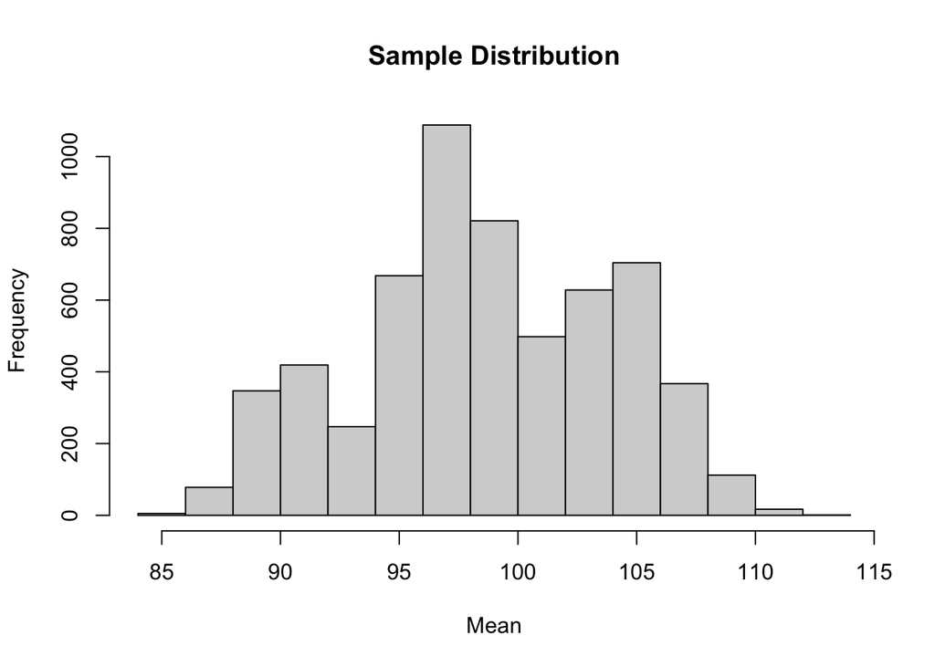

```r
hist(sample_dist$sampleMean,main="Sample Distribution",xlab="Mean")
```

The distribution is somewhat normal, not exactly but close

Standard error of mean for first sample

```r
se_mean
```

```
## [1]  9.634  9.155  9.830 10.120 10.500 10.449
```

Standard error of known population standard deviations for each decade

```r
results$sd/(sqrt(5651))
```

```
## [1] 0.3485465 0.2299863 0.2543957 0.2554963 0.2824416 0.2389063
```

Standard error as esitmated from sampling distribution of sample means

```r
sample_dist$sampleMean/sqrt(100)
```

[output not shown]

## Challenge 2

What is the probability that she will see 9 or fewer bees arrive during any given session?

```r
l <- 12
ppois(9,l)
```

```
## [1] 0.2423922
```

What is the probability that she will see no bees arrive in a session?

```r
ppois(0,l)
```

```
## [1] 6.144212e-06
```

What is the probability that she will see exactly 5 bees arrive in a session?

```r
dpois(5,l)
```

```
## [1] 0.01274064
```

```r
ppois(19,l,lower.tail=F)
```

```
## [1] 0.02127977
```

Plot the relevant Poisson mass function over the values in range 0 ≤ x ≤ 24.

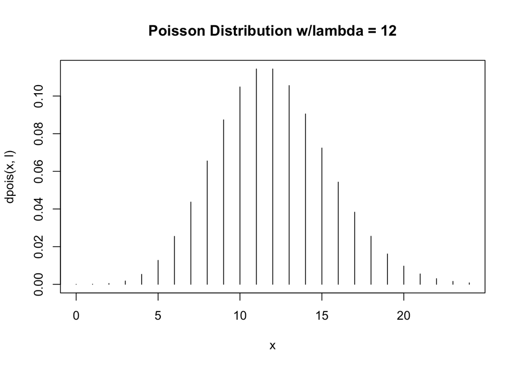

```r
x<-c(0:24)
plot(x,dpois(x,l),type='h',main="Poisson Distribution w/lambda = 12")
```

Using the rpois() function, simulate 1460 results from this distribution (i.e., 4 full years of morning monitoring sessions).

```r
r<-rpois(1460,l)
```

Plot the simulated results using the histogram() function from the {mosaic} package and use xlim() to set the horizontal limits to be from 0 to 24. How do your simulated results compare to the shape of the probability mass function you plotted above?

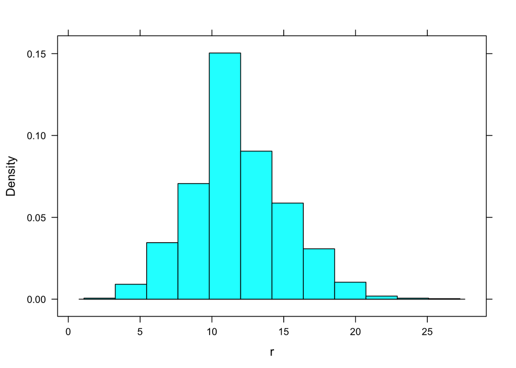

```r
histogram(r,xlim(0,24))
```

My results are pretty much the same as the probability mass function I plotted above.

## Challenge 3

Loading in data

```r
d<-read_csv("https://raw.githubusercontent.com/difiore/ada-2021-datasets/master/zombies.csv",col_names=T)
head(d)
```

```
## # A tibble: 6 x 10
##      id first_name last_name gender height weight zombies_killed
##   <dbl> <chr>      <chr>     <chr>   <dbl>  <dbl>          <dbl>
## 1     1 Sarah      Little    Female   62.9   132.              2
## 2     2 Mark       Duncan    Male     67.8   146.              5
## 3     3 Brandon    Perez     Male     72.1   153.              1
## 4     4 Roger      Coleman   Male     66.8   130.              5
## 5     5 Tammy      Powell    Female   64.7   132.              4
## 6     6 Anthony    Green     Male     71.2   153.              1
## # … with 3 more variables: years_of_education <dbl>, major <chr>, age <dbl>
```

Getting mean and sd

```r
colMeans(d[ , c(5, 6,7,8,10)])
```

```
##             height             weight     zombies_killed years_of_education
##           67.63010          143.90748            2.99200            2.99600
##                age
##           20.04696
```

```r
n<-1000
popSD<-function(x){sqrt((n-1)/n) * sd(x)}
apply(d[ , c(5, 6,7,8,10)], 2, popSD)
```

```
##             height             weight     zombies_killed years_of_education
##           4.307970          18.391857           1.747551           1.675704
##                age
##           2.963583
```

Boxplots

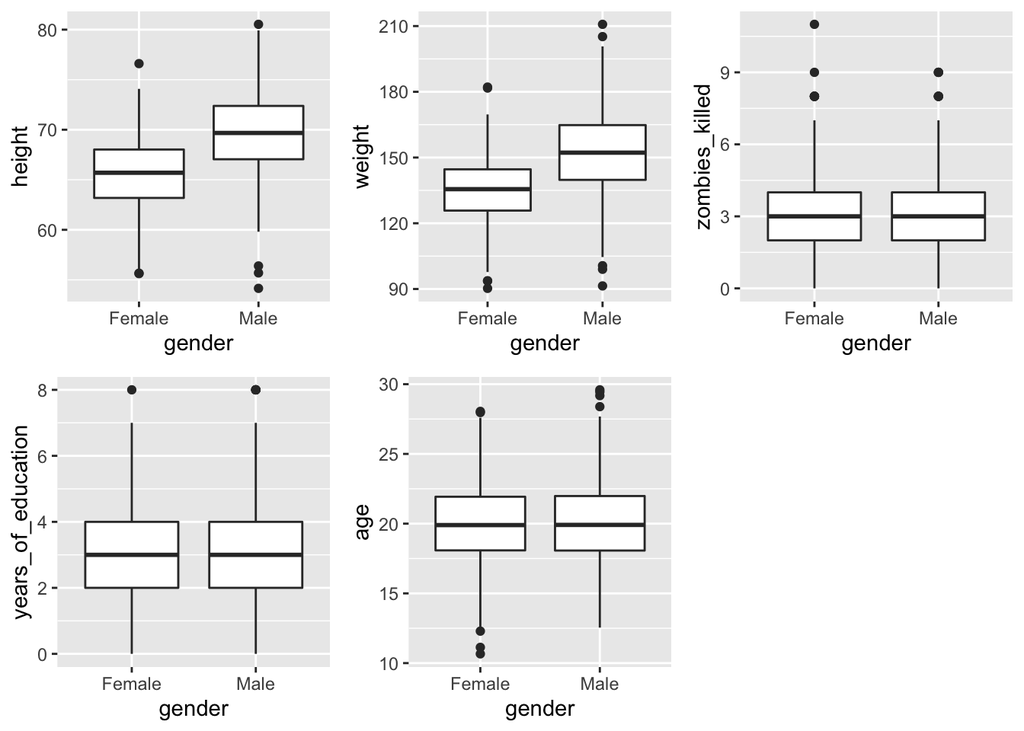

```r
p1<-ggplot(d, aes(x=gender, y=height)) +
  geom_boxplot()
p2<-ggplot(d, aes(x=gender, y=weight)) +
  geom_boxplot()
p3<-ggplot(d, aes(x=gender, y=zombies_killed)) +
  geom_boxplot()
p4<-ggplot(d, aes(x=gender, y=years_of_education)) +
  geom_boxplot()
p5<-ggplot(d,aes(x=gender, y=age)) +
  geom_boxplot()

grid.arrange(p1, p2,p3,p4,p5, nrow=2, ncol=3)
```

Scatterplots

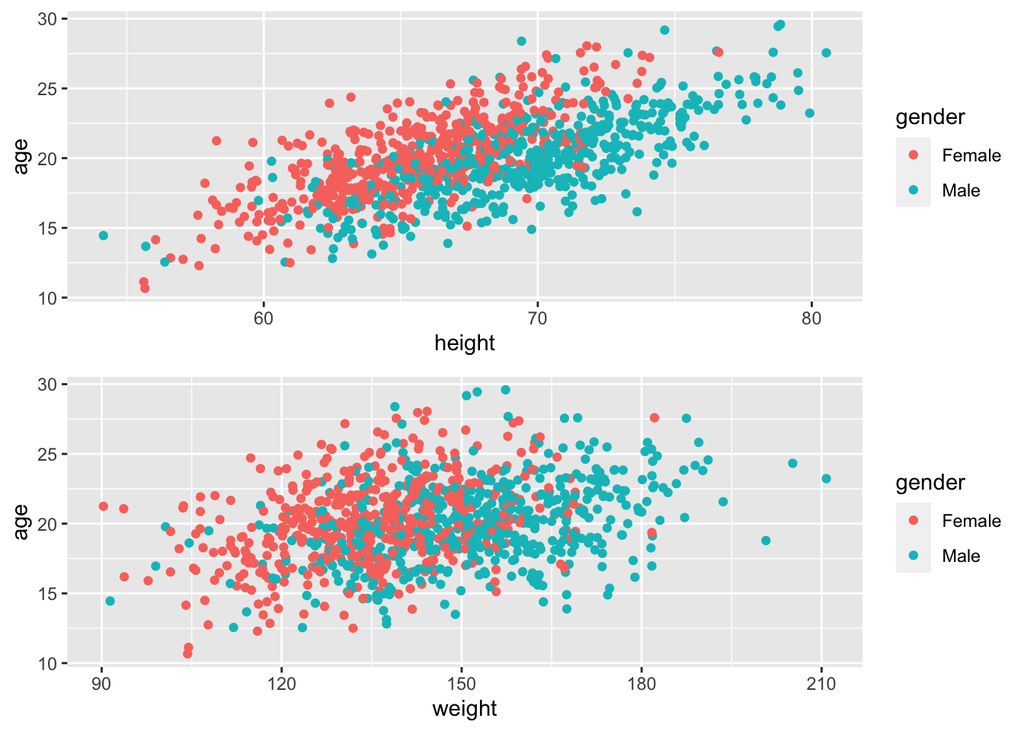

```r
p1<-ggplot(d, aes(x=height, y=age,color=gender)) + geom_point()
p2<-ggplot(d, aes(x=weight, y=age, color=gender)) + geom_point()

grid.arrange(p1,p2,nrow=2)
```

Height seems more correlated than weight with age - seems to be a direct relationship

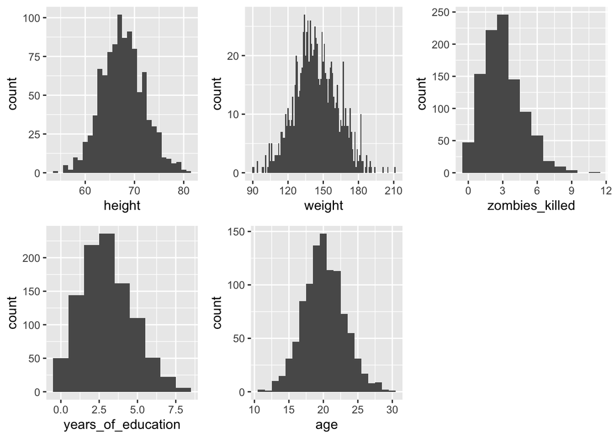

```r
p1<-ggplot(d, aes(x=height)) +geom_histogram(binwidth=1)
p2<-ggplot(d, aes(x=weight)) +geom_histogram(binwidth=1)
p3<-ggplot(d, aes(x=zombies_killed)) +geom_histogram(binwidth=1)
p4<-ggplot(d, aes(x=years_of_education)) +geom_histogram(binwidth=1)
p5<-ggplot(d, aes(x=age)) +geom_histogram(binwidth=1)

grid.arrange(p1, p2,p3,p4,p5, nrow=2, ncol=3)
```

q-q plots

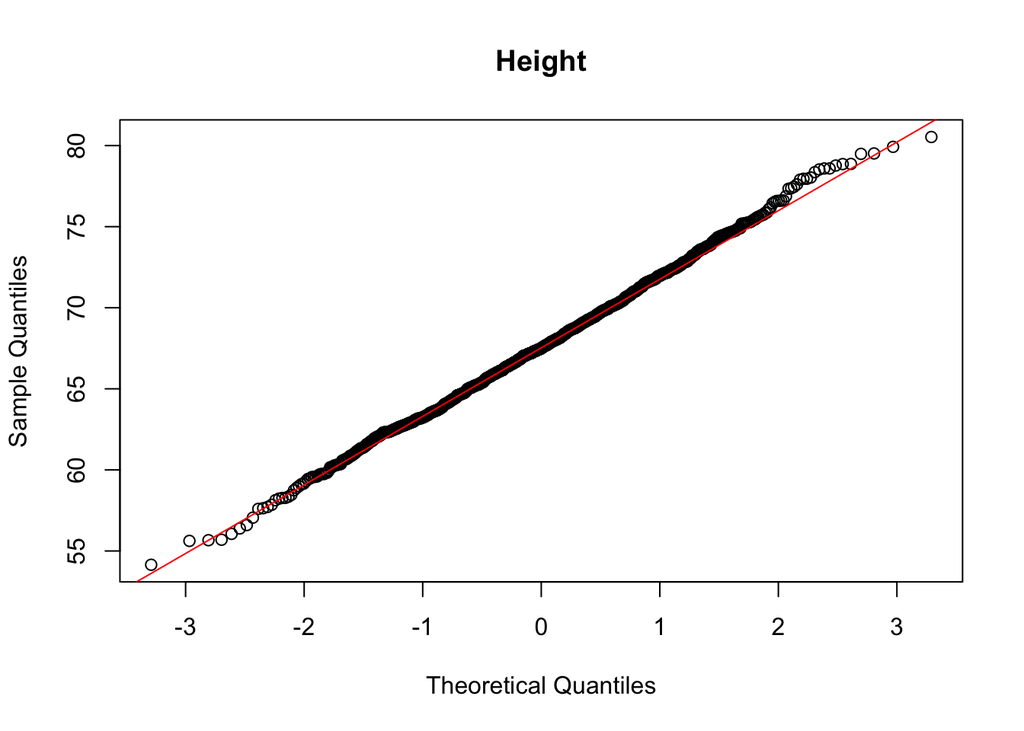

```r
qqnorm(d$height, main = "Height")
qqline(d$height, col = "red")
```

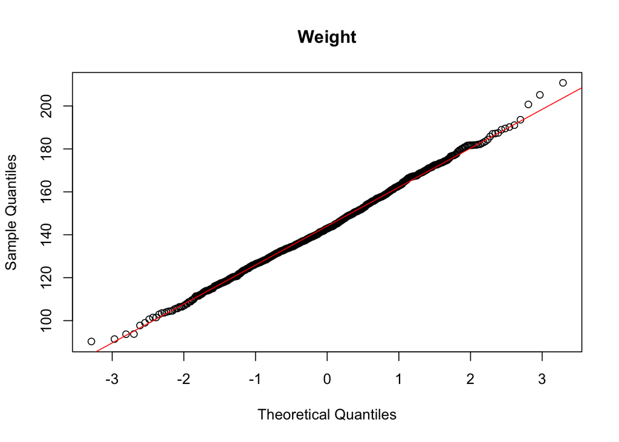

```r
qqnorm(d$weight, main = "Weight")
qqline(d$weight, col = "red")
```

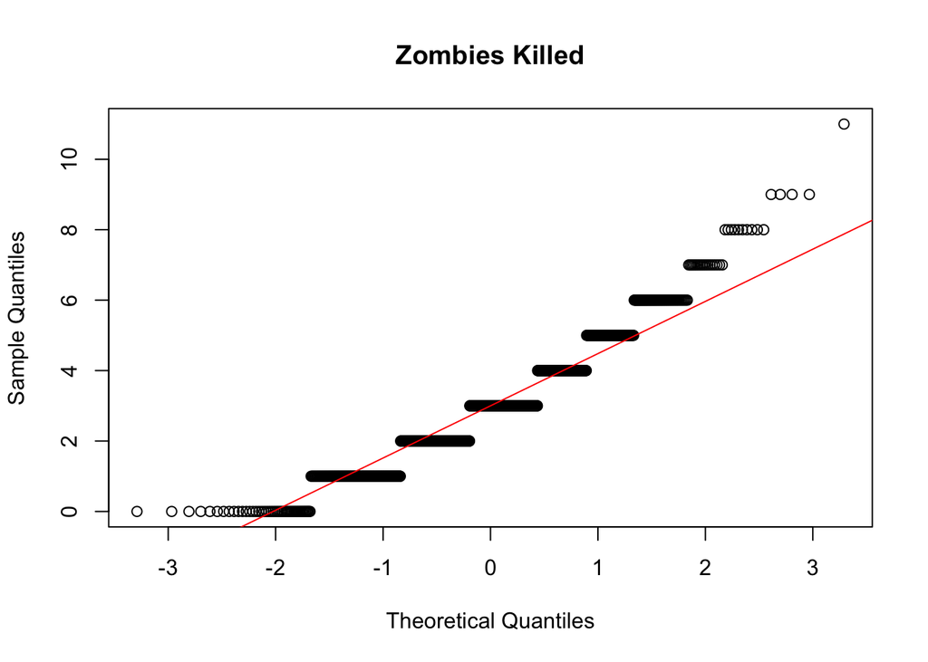

```r
qqnorm(d$zombies_killed, main = "Zombies Killed")
qqline(d$zombies_killed, col = "red")
```

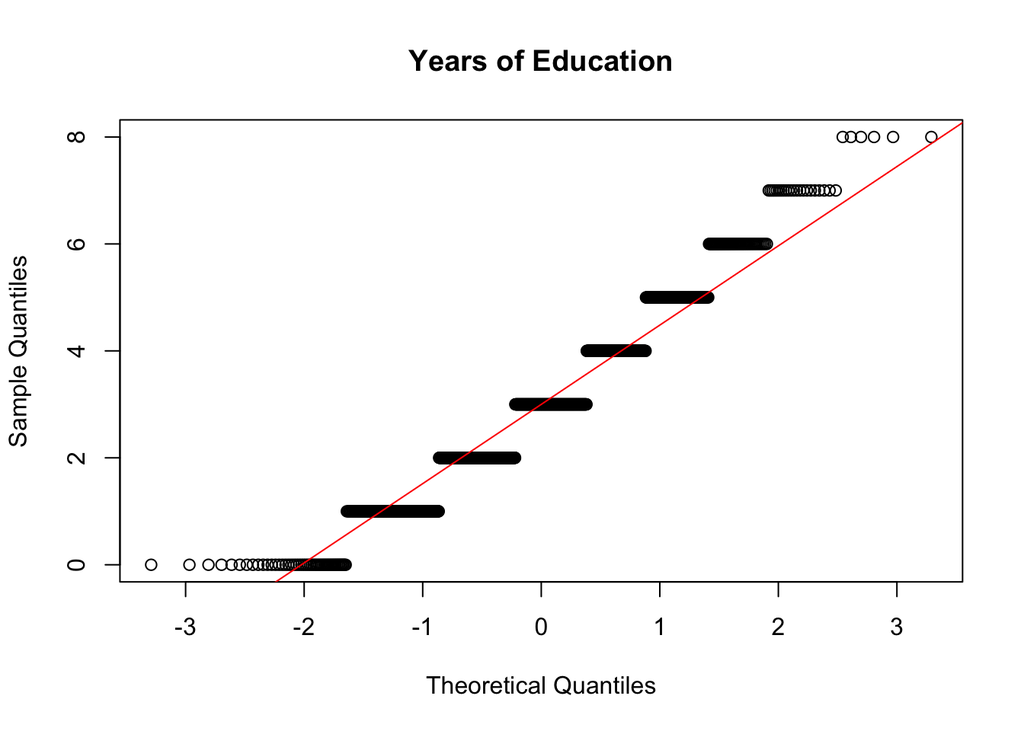

```r
qqnorm(d$years_of_education, main = "Years of Education")
qqline(d$years_of_education, col = "red")
```

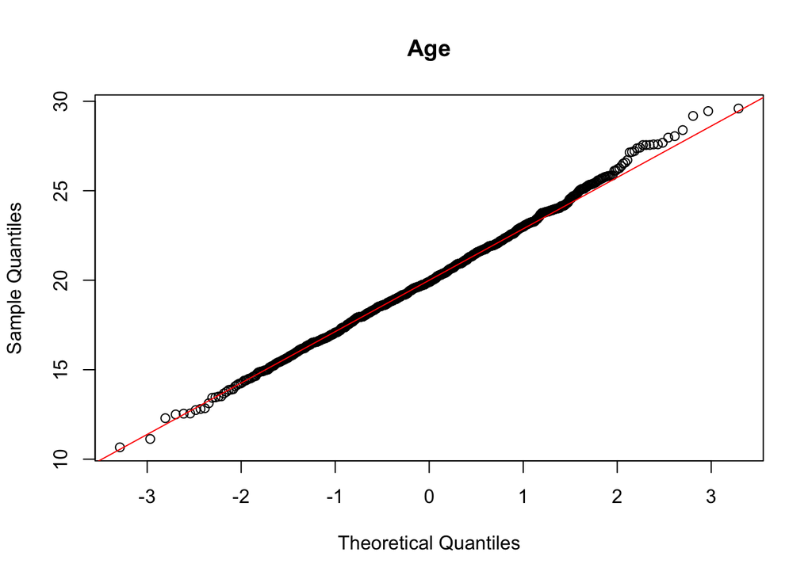

```r
qqnorm(d$age, main = "Age")
qqline(d$age, col = "red")
```

It looks like all but zombies killed and years of education are normally distributed

Taking a sample

```r
set.seed(50)
sample <- d %>% sample_n(50,replace=F)
```

Mean, SD, SE of each variable

```r
print(means<-colMeans(sample[ ,c(5,6,7,8,10)]))
```

```
##             height             weight     zombies_killed years_of_education
##           67.68985          145.05526            3.08000            3.20000
##                age
##           19.80056
```

```r
print(sds<-apply(sample[ , c(5, 6,7,8,10)], 2, sd))
```

```
##             height             weight     zombies_killed years_of_education
##           4.227690          17.978548           1.849876           1.590790
##                age
##           2.943822
```

```r
print(se_mean <- means/(sqrt(50)))
```

```
##             height             weight     zombies_killed years_of_education
##          9.5727903         20.5139114          0.4355778          0.4525483
##                age
##          2.8002219
```

```r
print(se_sds<-sds/(sqrt(50)))
```

```
##             height             weight     zombies_killed years_of_education
##          0.5978856          2.5425507          0.2616120          0.2249717
##                age
##          0.4163193
```

Getting confidence intervals

```r
error<- qnorm(.975)*sds/sqrt(50)
print(lower<-means-error)
```

```
##             height             weight     zombies_killed years_of_education
##          66.518015         140.071951           2.567250           2.759064
##                age
##          18.984588
```

```r
print(upper<-means+error)
```

```
##             height             weight     zombies_killed years_of_education
##          68.861684         150.038566           3.592750           3.640936
##                age
##          20.616530
```

```r
sample_dist<-do(50) * d %>%sample_n(50,replace=F)
m<-aggregate(.~.index, data=sample_dist[ ,c(5,6,7,8,10,12)], mean)
standev<-aggregate(.~.index, data=sample_dist[ ,c(5,6,7,8,10,12)], sd)
print(means<-colMeans(m[ ,c(2,3,4,5,6)]))
```

```
##             height             weight     zombies_killed years_of_education
##           67.70222          144.13246            2.98400            3.04920
##                age
##           20.09991
```

```r
print(sds<-apply(m[ , c(2,3,4,5,6)], 2, sd))
```

```
##             height             weight     zombies_killed years_of_education
##          0.6146054          2.3507606          0.2113900          0.2576253
##                age
##          0.4993442
```

Confidence intervals

```r
error<- qnorm(.975)*sds/sqrt(50)
print(lower_dist<-means-error)
```

```
##             height             weight     zombies_killed years_of_education
##          67.531867         143.480871           2.925407           2.977791
##                age
##          19.961505
```

```r
print(upper_dist<-means+error)
```

```
##             height             weight     zombies_killed years_of_education
##          67.872581         144.784042           3.042593           3.120609
##                age
##          20.238322
```

```r
sds
```

```
##             height             weight     zombies_killed years_of_education
##          0.6146054          2.3507606          0.2113900          0.2576253
##                age
##          0.4993442
```

```r
se_sds
```

```
##             height             weight     zombies_killed years_of_education
##          0.5978856          2.5425507          0.2616120          0.2249717
##                age
##          0.4163193
```

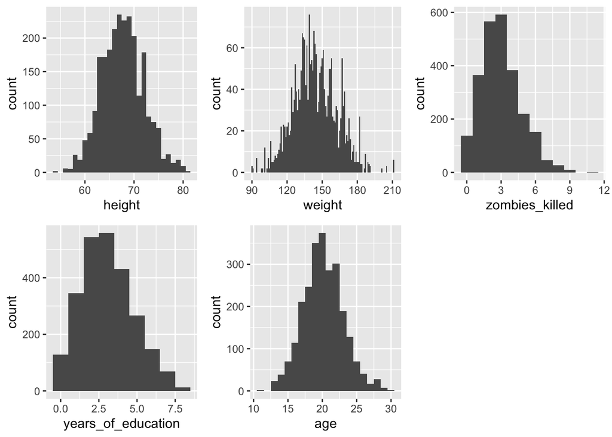

```r
p1<-ggplot(sample_dist, aes(x=height)) +geom_histogram(binwidth=1)
p2<-ggplot(sample_dist, aes(x=weight)) +geom_histogram(binwidth=1)
p3<-ggplot(sample_dist, aes(x=zombies_killed)) +geom_histogram(binwidth=1)
p4<-ggplot(sample_dist, aes(x=years_of_education)) +geom_histogram(binwidth=1)
p5<-ggplot(sample_dist, aes(x=age)) +geom_histogram(binwidth=1)

grid.arrange(p1, p2,p3,p4,p5, nrow=2, ncol=3)
```

```r
upper
```

```
##             height             weight     zombies_killed years_of_education
##          68.861684         150.038566           3.592750           3.640936
##                age
##          20.616530
```

```r
upper_dist
```

```
##             height             weight     zombies_killed years_of_education
##          67.872581         144.784042           3.042593           3.120609
##                age
##          20.238322
```

```r
lower
```

```
##             height             weight     zombies_killed years_of_education
##          66.518015         140.071951           2.567250           2.759064
##                age
##          18.984588
```

```r
lower_dist
```

```
##             height             weight     zombies_killed years_of_education
##          67.531867         143.480871           2.925407           2.977791
##                age
##          19.961505
```